# Peer-graded Assignment: Course Project 1

Made by F. Janga

24 november 2016

## Loading and preprocessing the data

#### Show any code that is needed to

#### 1.Load the data (i.e. read.csv())

```r
#Setting the working directory and loading libraries
setwd("//gasunie.nl/NetwerkMappen/PersoonlijkeData/EX27825/UserData/Documents/Coursera/Coursera/Nieuwe map/activity_zip~")
library(ggplot2)
#Read in the data
activitydata <- read.csv("activity.csv")
```

#### 2.Process/transform the data (if necessary) into a format suitable for your analysis

```r
#Setting the date variable
activitydata$date <- as.Date(activitydata$date, format="%Y-%m-%d")
```

## What is mean total number of steps taken per day?

For this part of the assignment, you can ignore the missing values in the dataset.

#### 1.Calculate the total number of steps taken per day

```r
#Create a dataset with the total steps per day
numsteps <- aggregate(steps~date,activitydata,sum, na.rm=TRUE)
```

#### 2.If you do not understand the difference between a histogram and a barplot, research the difference between them. Make a histogram of the total number of steps taken each day.

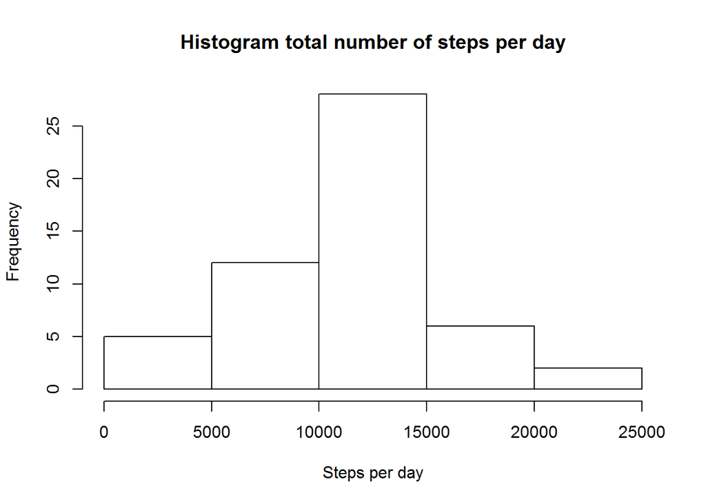

```r
#Create a histogram with the total steps per day
stepsperday <- hist(numsteps$steps, main="Histogram total number of steps per day", xlab="Steps per day" )
```

#### 3.Calculate and report the mean and median of the total number of steps taken per day

```r
#Calculate the mean of the total number of steps per day
mean(numsteps$steps)
```

```
## [1] 10766.19
```

```r
#Calculate the median of the total number of steps per day
median(numsteps$steps)
```

```
## [1] 10765
```

## What is the average daily activity pattern?

#### 1.Make a time series plot (i.e. type = “l”) of the 5-minute interval (x-axis) and the average number of steps taken, averaged across all days (y-axis).

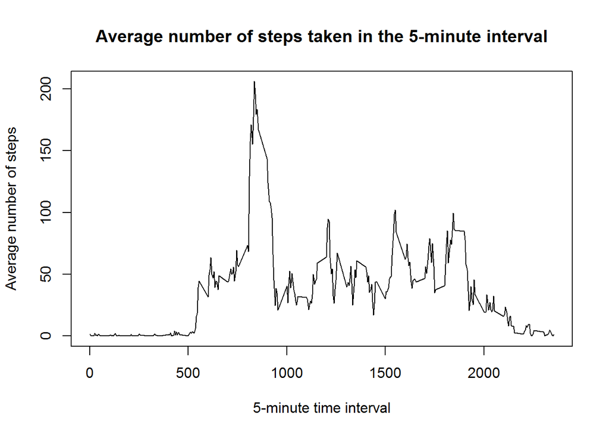

```r
#Make a dataset with the average steps per day per interval
stepsinterval <- aggregate(steps~interval,activitydata,mean, na.rm=TRUE)

#Make a plot of the new dataset
plot(stepsinterval$interval,stepsinterval$steps, type='l', main ="Average number of steps taken in the 5-minute interval", xlab ="5-minute time interval", ylab="Average number of steps")
```

#### 2.Which 5-minute interval, on average across all the days in the dataset, contains the maximum number of steps?

```r
#Calculate in which interval the maximum numbers of steps are.
maxnum <- which.max(stepsinterval$steps)
```

[output not shown]

## Imputing missing values

Note that there are a number of days/intervals where there are missing values (coded as NA). The presence of missing days may introduce bias into some calculations or summaries of the data.

#### 1.Calculate and report the total number of missing values in the dataset (i.e. the total number of rows with NAs)

```r
#Calculate the sum of the NA values
sum(is.na(activitydata))
```

```
## [1] 2304
```

#### 2.Devise a strategy for filling in all of the missing values in the dataset.

The strategy does not need to be sophisticated. For example, you could use the mean/median for that day, or the mean for that 5-minute interval, etc.

#### 3.Create a new dataset that is equal to the original dataset but with the missing data filled in.

```r
#My strategy is to change all the missing values into zeros.
#First make a new dataset
activitydata2 <- activitydata

#Change all the NA values into zero.
activitydata2[is.na(activitydata2)] <- 0
```

#### 4.Make a histogram of the total number of steps taken each day and

Calculate and report the mean and median total number of steps taken per day.

Do these values differ from the estimates from the first part of the assignment?

What is the impact of imputing missing data on the estimates of the total daily number of steps?

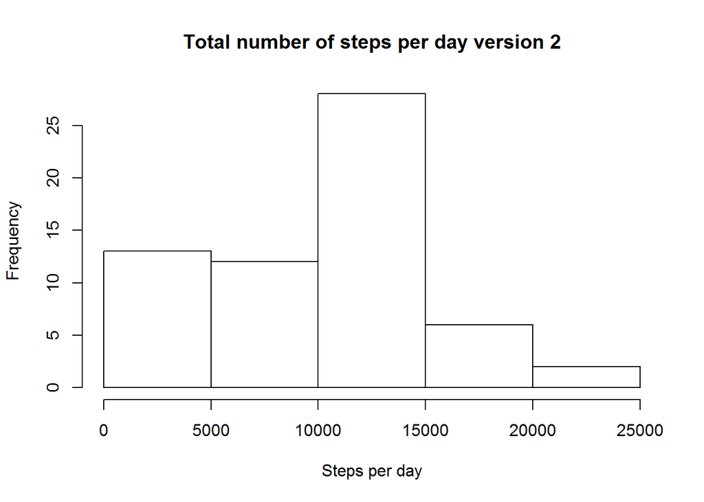

```r
numsteps2 <- aggregate(steps~date,activitydata2,sum)
hist(numsteps2$steps, main ="Total number of steps per day version 2", xlab = "Steps per day")
```

```r
mean(numsteps2$steps)
```

```
## [1] 9354.23
```

```r
median(numsteps2$steps)
```

```
## [1] 10395
```

The values from the mean and the median differ somehow from the first part of the assignment. Since the missing values are zeros, the mean and the median are a little lower.

## Are there differences in activity patterns between weekdays and weekends?

For this part the weekdays() function may be of some help here. Use the dataset with the filled-in missing values for this part.

#### 1.Create a new factor variable in the dataset with two levels - “weekday” and “weekend” indicating whether a given date is a weekday or weekend day.

```r
#Create a new column called 'Days' which shows the weekday
activitydata2["Days"]<- weekdays(activitydata2$date)

#Change the days in weekend or weekday
activitydata2$Days <- ifelse(activitydata2$Days=='zaterdag'| activitydata2$Days=='zondag', 'weekend', 'weekday')
```

#### 2.Make a panel plot containing a time series plot (i.e. type = “l”) of the 5-minute interval (x-axis) and the average number of steps taken, averaged across all weekday days or weekend days (y-axis).

See the README file in the GitHub repository to see an example of what this plot should look like using simulated data.

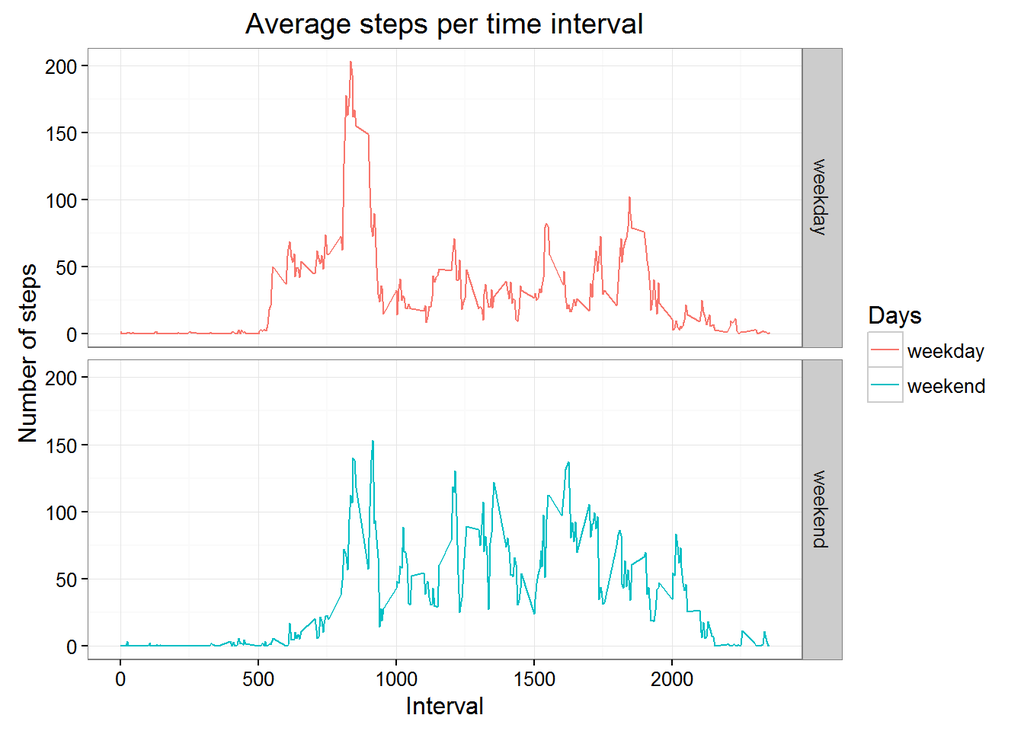

```r
#Create a dataset with the average number of steps per interval per weekday
activitydata3 <- aggregate(steps ~ interval+Days, activitydata2, mean)

#Make the plot with 2 facets
g <- ggplot(data=activitydata3, aes(interval, steps))
g + geom_line(aes(colour=Days))+ theme_bw() + ggtitle("Average steps per time interval") + labs(x="Interval", y="Number of steps")+ facet_grid(Days ~ .)
```